# MovieLens Project Questions

### Project - MovieLens Data Analysis

The GroupLens Research Project is a research group in the Department of Computer Science and Engineering at the University of Minnesota. The data is widely used for collaborative filtering and other filtering solutions. However, we will be using this data to act as a means to demonstrate our skill in using Python to “play” with data.

#### Domain

Internet and Entertainment

**Note that the project will need you to apply the concepts of groupby and merging extensively.**

#### 1. Import the necessary packages - 2.5 marks

```python
import pandas as pd
import numpy as np
import matplotlib.pyplot as plt
import seaborn as sns

%matplotlib inline
sns.set(color_codes=True)
```

#### 2. Read the 3 datasets into dataframes - 2.5 marks

```python
df_Ratings = pd.read_csv("Data.csv")
df_Users = pd.read_csv("user.csv")
df_Movies = pd.read_csv("item.csv")
```

#### 3. Apply info, shape, describe, and find the number of missing values in the data - 5 marks

```python
# The three datasets are explored in sequence
```

```python
# Dataset 1 - Ratings

print(df_Ratings.info())
print('')
print(df_Ratings.shape)
df_Ratings.describe()
```

```
<class 'pandas.core.frame.DataFrame'>
RangeIndex: 100000 entries, 0 to 99999
Data columns (total 4 columns):
 #   Column     Non-Null Count   Dtype
---  ------     --------------   -----
 0   user id    100000 non-null  int64
 1   movie id   100000 non-null  int64
 2   rating     100000 non-null  int64
 3   timestamp  100000 non-null  int64
dtypes: int64(4)
memory usage: 3.1 MB
None

(100000, 4)
```

|  | user id | movie id | rating | timestamp |
| --- | --- | --- | --- | --- |
| count | 100000.00000 | 100000.000000 | 100000.000000 | 1.000000e+05 |
| mean | 462.48475 | 425.530130 | 3.529860 | 8.835289e+08 |
| std | 266.61442 | 330.798356 | 1.125674 | 5.343856e+06 |
| min | 1.00000 | 1.000000 | 1.000000 | 8.747247e+08 |
| 25% | 254.00000 | 175.000000 | 3.000000 | 8.794487e+08 |
| 50% | 447.00000 | 322.000000 | 4.000000 | 8.828269e+08 |
| 75% | 682.00000 | 631.000000 | 4.000000 | 8.882600e+08 |
| max | 943.00000 | 1682.000000 | 5.000000 | 8.932866e+08 |

```python
# Observations:
# Examination of the data suggests two keys/indexes are used to identify records in other sources
# 'user id' and 'movie id', and the data then consists of a 'rating' in integer (int64) form.
# The .info() result shows there are no null/missing values.
# The .shape() result shows there are 100,000 ratings in this source.
# The 5 number analysis for 'user id' and 'movie id' in the .describe() result is
# irrelevant as these are keys/indexes for other data. However, the result for 'rating'
# suggests a mean rating of 3.5, with a higher median of 4 suggesting a slightly
# left skewed distribution, also noting the maximum value in the range is 5.
```

```python
# Dataset 2 - Users

print(df_Users.info())
print('')
print(df_Users.shape)
df_Users.describe()
```

```
<class 'pandas.core.frame.DataFrame'>
RangeIndex: 943 entries, 0 to 942
Data columns (total 5 columns):
 #   Column      Non-Null Count  Dtype
---  ------      --------------  -----
 0   user id     943 non-null    int64
 1   age         943 non-null    int64
 2   gender      943 non-null    object
 3   occupation  943 non-null    object
 4   zip code    943 non-null    object
dtypes: int64(2), object(3)
memory usage: 37.0+ KB
None

(943, 5)
```

|  | user id | age |
| --- | --- | --- |
| count | 943.000000 | 943.000000 |
| mean | 472.000000 | 34.051962 |
| std | 272.364951 | 12.192740 |
| min | 1.000000 | 7.000000 |
| 25% | 236.500000 | 25.000000 |
| 50% | 472.000000 | 31.000000 |
| 75% | 707.500000 | 43.000000 |
| max | 943.000000 | 73.000000 |

```python
# Observations:
# This datasource contains demographic data for users, including age, gender, occupation
# and zip code. The datasource appears to contain a unique identifier 'user id', which is
# used in the Ratings junction datasource to associate users with their ratings of different
# movies.
# The .info() result shows there are no null/missing values.
# The .shape() result shows there are 943 users in this source
# There is only one numeric observation in each row which is the user's age, and the 5 number
# result shows the average age of reviewers is 34, with a lower median of 31 suggesting
# a slightly right skewed distribution (younger).
```

```python
# Dataset 3 - Movies

print(df_Movies.info())
print('')
print(df_Movies.shape)
df_Movies.describe()
```

```
<class 'pandas.core.frame.DataFrame'>
RangeIndex: 1681 entries, 0 to 1680
Data columns (total 22 columns):
 #   Column        Non-Null Count  Dtype
---  ------        --------------  -----
 0   movie id      1681 non-null   int64
 1   movie title   1681 non-null   object
 2   release date  1681 non-null   object
 3   unknown       1681 non-null   int64
 4   Action        1681 non-null   int64
 5   Adventure     1681 non-null   int64
 6   Animation     1681 non-null   int64
 7   Childrens     1681 non-null   int64
 8   Comedy        1681 non-null   int64
 9   Crime         1681 non-null   int64
 10  Documentary   1681 non-null   int64
 11  Drama         1681 non-null   int64
 12  Fantasy       1681 non-null   int64
 13  Film-Noir     1681 non-null   int64
 14  Horror        1681 non-null   int64
 15  Musical       1681 non-null   int64
 16  Mystery       1681 non-null   int64
 17  Romance       1681 non-null   int64
 18  Sci-Fi        1681 non-null   int64
 19  Thriller      1681 non-null   int64
 20  War           1681 non-null   int64
 21  Western       1681 non-null   int64
dtypes: int64(20), object(2)
memory usage: 289.0+ KB
None

(1681, 22)
```

|  | movie id | unknown | Action | Adventure | Animation | Childrens | Comedy | Crime | Documentary | Drama | Fantasy | Film-Noir | Horror | Musical | Mystery | Romance | Sci-Fi | Thriller | War | Western |
| --- | --- | --- | --- | --- | --- | --- | --- | --- | --- | --- | --- | --- | --- | --- | --- | --- | --- | --- | --- | --- |
| count | 1681.000000 | 1681.000000 | 1681.000000 | 1681.000000 | 1681.000000 | 1681.000000 | 1681.000000 | 1681.000000 | 1681.000000 | 1681.000000 | 1681.000000 | 1681.000000 | 1681.000000 | 1681.000000 | 1681.000000 | 1681.000000 | 1681.000000 | 1681.000000 | 1681.000000 | 1681.000000 |
| mean | 841.841761 | 0.000595 | 0.149316 | 0.080309 | 0.024985 | 0.072576 | 0.300416 | 0.064842 | 0.029744 | 0.431291 | 0.013087 | 0.014277 | 0.054729 | 0.033314 | 0.036288 | 0.146936 | 0.060083 | 0.149316 | 0.042237 | 0.016062 |
| std | 485.638077 | 0.024390 | 0.356506 | 0.271852 | 0.156126 | 0.259516 | 0.458576 | 0.246321 | 0.169931 | 0.495404 | 0.113683 | 0.118667 | 0.227519 | 0.179507 | 0.187061 | 0.354148 | 0.237712 | 0.356506 | 0.201189 | 0.125751 |
| min | 1.000000 | 0.000000 | 0.000000 | 0.000000 | 0.000000 | 0.000000 | 0.000000 | 0.000000 | 0.000000 | 0.000000 | 0.000000 | 0.000000 | 0.000000 | 0.000000 | 0.000000 | 0.000000 | 0.000000 | 0.000000 | 0.000000 | 0.000000 |
| 25% | 422.000000 | 0.000000 | 0.000000 | 0.000000 | 0.000000 | 0.000000 | 0.000000 | 0.000000 | 0.000000 | 0.000000 | 0.000000 | 0.000000 | 0.000000 | 0.000000 | 0.000000 | 0.000000 | 0.000000 | 0.000000 | 0.000000 | 0.000000 |
| 50% | 842.000000 | 0.000000 | 0.000000 | 0.000000 | 0.000000 | 0.000000 | 0.000000 | 0.000000 | 0.000000 | 0.000000 | 0.000000 | 0.000000 | 0.000000 | 0.000000 | 0.000000 | 0.000000 | 0.000000 | 0.000000 | 0.000000 | 0.000000 |
| 75% | 1262.000000 | 0.000000 | 0.000000 | 0.000000 | 0.000000 | 0.000000 | 1.000000 | 0.000000 | 0.000000 | 1.000000 | 0.000000 | 0.000000 | 0.000000 | 0.000000 | 0.000000 | 0.000000 | 0.000000 | 0.000000 | 0.000000 | 0.000000 |
| max | 1682.000000 | 1.000000 | 1.000000 | 1.000000 | 1.000000 | 1.000000 | 1.000000 | 1.000000 | 1.000000 | 1.000000 | 1.000000 | 1.000000 | 1.000000 | 1.000000 | 1.000000 | 1.000000 | 1.000000 | 1.000000 | 1.000000 | 1.000000 |

```python
# Observations:
# This datasource contains title, release date, and genre information for movies.
# The datasource appears to contain a unique identifier 'movie id', which is
# used in the Ratings junction datasource to associate movies with the ratings given by
# different users. Observation of genre columns suggests this data is given in boolean form
# to indicate whether a movie is of that genre.
# The .info() result shows there are no null/missing values.
# The .shape() result shows there are 1681 movies in this source
# The data is categorical so the 5 number summary not particularly useful. The mean for a set of
# booleans can offer some clues for investigation in terms of which genres are observed more
# or less often (i.e. above or below 0.5), but on it's own this is not supportive of any
# conclusions about the data.
```

#### 4. Find the number of movies per genre using the item data - 5 marks

```python
# Use the sum function to sum the Movies dataframe, with the numeric_only parameter to
# exclude the movie title and release date. Then, drop the sum of the movie ids (irrelevant),
# and as we're only interested in genres, and 'unknown' is not a genre, drop this as well,
# and create a new DataFrame df_GenreCounts from the result, which has genre names as the index.

df_GenreCounts = pd.DataFrame((df_Movies.sum(numeric_only=True)).drop(labels=['movie id','unknown']), columns=['Count'])

print(df_GenreCounts)
```

```
             Count
Action         251
Adventure      135
Animation       42
Childrens      122
Comedy         505
Crime          109
Documentary     50
Drama          725
Fantasy         22
Film-Noir       24
Horror          92
Musical         56
Mystery         61
Romance        247
Sci-Fi         101
Thriller       251
War             71
Western         27
```

```python
# The dataframe can optionally be re-indexed to have the genre names as a column

df_GenreCounts.reset_index(inplace=True)
df_GenreCounts.rename(columns={'index':'Genre'}, inplace=True)

print(df_GenreCounts)
```

```
          Genre  Count
0        Action    251
1     Adventure    135
2     Animation     42
3     Childrens    122
4        Comedy    505
5         Crime    109
6   Documentary     50
7         Drama    725
8       Fantasy     22
9     Film-Noir     24
10       Horror     92
11      Musical     56
12      Mystery     61
13      Romance    247
14       Sci-Fi    101
15     Thriller    251
16          War     71
17      Western     27
```

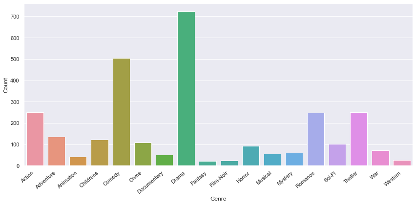

```python
# Observing that the resulting counts are widely spread, finding the number of movies per genre
# can usefully be accompanied by a barplot (with some label adjustments for readability). What
# can be observed from this visualisation is the frequency of observation of the Drama and
# Comedy genres for this colleciton of movies.

plt.figure(figsize=(12,6))
ax = sns.barplot(df_GenreCounts['Genre'], df_GenreCounts['Count'])
ax.set_xticklabels(ax.get_xticklabels(), rotation=40, ha="right")
plt.tight_layout()
plt.show()
```

#### 5. Find the movies that have more than one genre - 2.5 marks

```python
# From exploring the data, we know the genre columns contain booleans that indicate whether
# a movie is of that genre, or not. So, finding the movies with more than one genre is done
# by summing the booleans, and dropping any results with a count of 1 or less.

# Drop the movie id, movie title, and release date fields, and sum the resulting dataframe by
# rows (axis=1). Name the results column 'Genre Count', and convert the result to a new temporary
# working dataframe df.
df = pd.DataFrame((df_Movies.drop(labels=['movie id','movie title','release date'], axis=1).sum(axis=1, numeric_only=True)),columns=['Genre Count'])

# Find the indexes of all rows in the dataframe where Genre Count is less than or equal to one,
# then drop these rows from the dataframe. The result is a dataframe with the
# Genre Count containing the sum of the genres observed for that movie, with all movies
# of only 1 genre (or none, in case there are observations in the dataset with no genre) dropped.
indexNames = df[df['Genre Count'] <= 1].index
df.drop(indexNames,inplace=True)

# Now join the results dataframe to the movie data to produce a result showing the movie id,
# the title of the movie, and the number of genres. Drop the same indexes from the source Movie
# dataframe (to exclude the movies with <= 1 genre) and create a new dataframe with the movie id
# and movie title columns, left joined to the dataframe containing the genre counts.
df_MultiGenreMovies = (pd.DataFrame((df_Movies.drop(indexNames))[['movie id','movie title']])).join(df,how='left')

# Reset the index for the new dataframe
df_MultiGenreMovies.reset_index(inplace=True)
df_MultiGenreMovies.drop(labels=['index'], axis=1, inplace=True)


print(df_MultiGenreMovies.shape)
print('\n')
print(df_MultiGenreMovies)
df_MultiGenreMovies.head()
```

```
(849, 3)


     movie id         movie title  Genre Count
0           1          Toy Story             3
1           2          GoldenEye             3
2           4         Get Shorty             3
3           5            Copycat             3
4           7     Twelve Monkeys             2
..        ...                 ...          ...
844      1669  MURDER and murder             3
845      1670            Tainted             2
846      1673             Mirage             2
847      1679          B. Monkey             2
848      1680      Sliding Doors             2

[849 rows x 3 columns]
```

|  | movie id | movie title | Genre Count |
| --- | --- | --- | --- |
| 0 | 1 | Toy Story | 3 |
| 1 | 2 | GoldenEye | 3 |
| 2 | 4 | Get Shorty | 3 |
| 3 | 5 | Copycat | 3 |
| 4 | 7 | Twelve Monkeys | 2 |

```python
# Observations:
# There are 849 movies in the datasource that are associated with more than one genre.
```

#### 6. Drop the movie where the genre is unknown - 2.5 marks

```python
# Find the indexes for rows where the 'unknown' column contains a boolean of 1.
indexNames = df_Movies[df_Movies['unknown'] == 1].index

# Use a for loop to iterate the indexes, to create some print() output which shows the
# movie/s that are to be dropped.
removed = 0
for i in indexNames:
    print("The movie '" + (df_Movies.iloc[i])['movie title'] + "' is of unknown genre and will be dropped.")
    removed = removed + 1
print(str(removed) + " movies will be dropped.\n")

# Drop the rows and create a new DataFrame df_MoviesWithKnownGenre from the result.
# This method preserves the integrity of the source data, otherwise this
# .drop() could be done with the inplace=True parameter
df_MoviesWithKnownGenre = pd.DataFrame(df_Movies.drop(indexNames))


print(df_MoviesWithKnownGenre.shape)
df_MoviesWithKnownGenre.head()
```

```
The movie 'Good Morning ' is of unknown genre and will be dropped.
1 movies will be dropped.

(1680, 22)
```

|  | movie id | movie title | release date | unknown | Action | Adventure | Animation | Childrens | Comedy | Crime | ... | Fantasy | Film-Noir | Horror | Musical | Mystery | Romance | Sci-Fi | Thriller | War | Western |
| --- | --- | --- | --- | --- | --- | --- | --- | --- | --- | --- | --- | --- | --- | --- | --- | --- | --- | --- | --- | --- | --- |
| 0 | 1 | Toy Story | 01-Jan-1995 | 0 | 0 | 0 | 1 | 1 | 1 | 0 | ... | 0 | 0 | 0 | 0 | 0 | 0 | 0 | 0 | 0 | 0 |
| 1 | 2 | GoldenEye | 01-Jan-1995 | 0 | 1 | 1 | 0 | 0 | 0 | 0 | ... | 0 | 0 | 0 | 0 | 0 | 0 | 0 | 1 | 0 | 0 |
| 2 | 3 | Four Rooms | 01-Jan-1995 | 0 | 0 | 0 | 0 | 0 | 0 | 0 | ... | 0 | 0 | 0 | 0 | 0 | 0 | 0 | 1 | 0 | 0 |
| 3 | 4 | Get Shorty | 01-Jan-1995 | 0 | 1 | 0 | 0 | 0 | 1 | 0 | ... | 0 | 0 | 0 | 0 | 0 | 0 | 0 | 0 | 0 | 0 |
| 4 | 5 | Copycat | 01-Jan-1995 | 0 | 0 | 0 | 0 | 0 | 0 | 1 | ... | 0 | 0 | 0 | 0 | 0 | 0 | 0 | 1 | 0 | 0 |

5 rows × 22 columns

```python
# Observations:
# The output of the for loop shows there is only one movie in the source data that has a genre
# of 'unknown' - the movie titled 'Good Morning'. The shape and .head() results show that only
# one row was dropped, with 1680 rows down from the 1681 observed in step 3 above.
```

### 7. Univariate plots of columns: 'rating', 'Age', 'release year', 'Gender' and 'Occupation' - 10 marks

```python
# Plot 1 - Rating
# Using a countplot as per the task requirements.
```

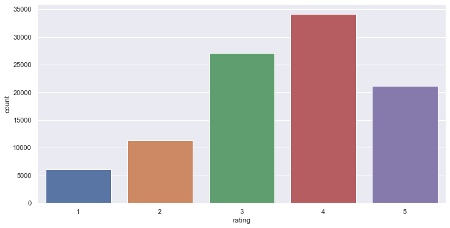

```python
plt.figure(figsize=(12,6))
sns.countplot(df_Ratings['rating']);
```

```python
# Observations:
# This visualisation supports the initial observations at step 3 above that the data
# has a left skew.
```

```python
# Plot 2 - Age
# Using a distplot as per requirements.
```

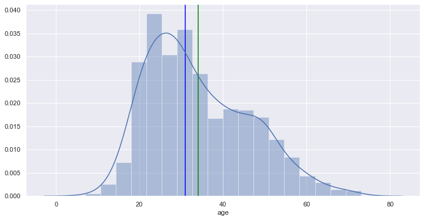

```python
plt.figure(figsize=(12,6))
plt.axvline(df_Users['age'].mean(),color='green',label='Mean')
plt.axvline(df_Users['age'].median(),color='blue',label='Median')
sns.distplot(df_Users['age']);
```

```python
# Observations:
# This visualisation also supports the initial observations at step 3 above that the data
# has a right skew. The highest frequency of ages for movie reviewers in this population are
# observed in the age range between approximately 20 and 35.
```

```python
# Plot 3 - Release Year
# Using a displot without kde as per requirements.
```

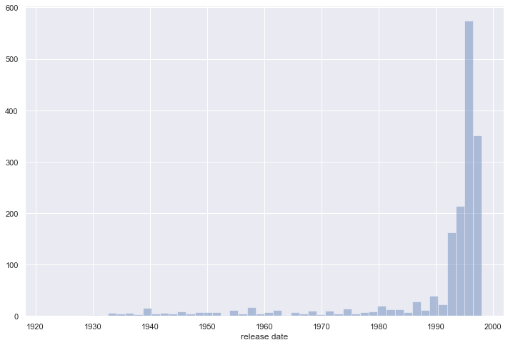

```python
# The release dates in the source data for Movies are given in the form dd-mmm-yyyy, so the
# year must be extracted to plot the distribution for release year. As we know the year is
# given as 4 digits, this can be done with a regular expression.

# Create a copy of the Movies dataframe.
df_ReleaseYears = df_Movies.copy()

# Replace the 'release date' values with the year, using the regex ?P<year>\d{4}
df_ReleaseYears['release date'] = df_Movies['release date'].str.extract('(?P<year>\d{4})').astype(int)

# Plot the result
plt.figure(figsize=(12,8))
sns.distplot(df_ReleaseYears['release date'], kde=False);
```

```python
# Observations:
# The plot is not particularly useful for visualising the comparative differences in
# the number of movies in this datasource that were released up to about 1990, as the
# extremely high number of observations in the mid-1990s compresses the scale.

# However, what the visualisation does tell us that this dataset predominantly contains data
# for movies released after about 1990. Every movie in this sample appears in
# the dataset because it has been reviewed by one of the people in the Users dataset - confirmed
# with a simple "isin" investigation:

# df = pd.DataFrame(df_Movies['movie id'].isin(df_Ratings['movie id']))
# indexNames = df[df['movie id'] == False].index

# This means that the Movies dataset dervies from the viewing and rating activity of a
# particular cohort of users, rather than being indicative of any general or industry trend.
# Noting that the age plot for the user cohort showed a right skew and the highest frequency
# of observations in the 20 to 35 age range, this visualisation of release years suggests
# an interesting question for further exploration, which is whether there is a correlation
# between the age of the user, and the release dates of the movies they choose to watch and
# review.
```

```python
# Plot 4 - Gender
# Using a countplot as per requirements.
```

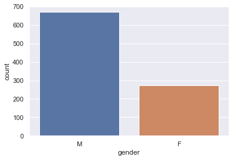

```python
sns.countplot(df_Users['gender']);
```

```python
# Observations:
# This plot shows that the user cohort contains more than twice as many males as females.
```

```python
# Plot 5 - Occupation
# Using a countplot as per requirements.
```

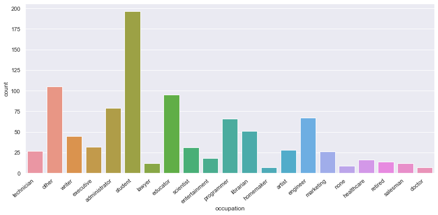

```python
plt.figure(figsize=(12,6))
ax = sns.countplot(df_Users['occupation']);
ax.set_xticklabels(ax.get_xticklabels(), rotation=40, ha="right")
plt.tight_layout()
plt.show()
```

```python
# Observations:
# The labels suggest some diversity in the occupations of this cohort of users. It also shows that
# the 'student' occupation is observed at a rate nearly twice the next highest occupation which is
# 'other'. The extent to which this is correlated to the age distribution noted above would be
# a follow up question suggested by this visualisation.
```

### 8. Visualize how popularity of genres has changed over the years - 10 marks

Note that you need to use the number of releases in a year as a parameter of popularity of a genre

Hint

1: you need to reach to a data frame where the release year is the index and the genre is the column names (one cell shows the number of release in a year in one genre) or vice versa. Once that is achieved, you can either use univariate plots or can use the heatmap to visualise all the changes over the years in one go.

Hint 2: Use groupby on the relevant column and use sum() on the same to find out the nuumber of releases in a year/genre.

```python
# The approach here is as suggested at point 1 above, which is to produce a dataframe
# where the release year is the index, and the genres are in column names with each value
# showing the total releases of that genre for the year.

# Create a temporary dataframe from the Movies data
df = df_Movies.copy()

# Prepare the data by dropping any movies with "unknown" genre
indexNames = df[df['unknown'] == 1].index
df.drop(indexNames, inplace=True)

# Replace all the release dates with the corresponding release year
df['release date'] = df_Movies['release date'].str.extract('(?P<year>\d{4})').astype(int)

# Drop the superfluous columns
df.drop(labels=['movie id','movie title','unknown'], axis=1, inplace=True)

# Use groupby on the year values now in 'release date' to create a DataFrameGroupBy object,
# then sum the columns to produce the total releases for the year, and convert to DataFrame
df_GenrePopularity = pd.DataFrame(df.groupby('release date').sum())

print(df_GenrePopularity.info())
print('')
df_GenrePopularity
```

```
<class 'pandas.core.frame.DataFrame'>
Int64Index: 71 entries, 1922 to 1998
Data columns (total 18 columns):
 #   Column       Non-Null Count  Dtype
---  ------       --------------  -----
 0   Action       71 non-null     int64
 1   Adventure    71 non-null     int64
 2   Animation    71 non-null     int64
 3   Childrens    71 non-null     int64
 4   Comedy       71 non-null     int64
 5   Crime        71 non-null     int64
 6   Documentary  71 non-null     int64
 7   Drama        71 non-null     int64
 8   Fantasy      71 non-null     int64
 9   Film-Noir    71 non-null     int64
 10  Horror       71 non-null     int64
 11  Musical      71 non-null     int64
 12  Mystery      71 non-null     int64
 13  Romance      71 non-null     int64
 14  Sci-Fi       71 non-null     int64
 15  Thriller     71 non-null     int64
 16  War          71 non-null     int64
 17  Western      71 non-null     int64
dtypes: int64(18)
memory usage: 10.5 KB
None
```

| release date | Action | Adventure | Animation | Childrens | Comedy | Crime | Documentary | Drama | Fantasy | Film-Noir | Horror | Musical | Mystery | Romance | Sci-Fi | Thriller | War | Western |
| --- | --- | --- | --- | --- | --- | --- | --- | --- | --- | --- | --- | --- | --- | --- | --- | --- | --- | --- |
| 1922 | 0 | 0 | 0 | 0 | 0 | 0 | 0 | 0 | 0 | 0 | 1 | 0 | 0 | 0 | 0 | 0 | 0 | 0 |
| 1926 | 0 | 0 | 0 | 0 | 0 | 0 | 0 | 1 | 0 | 0 | 0 | 0 | 0 | 0 | 0 | 0 | 0 | 0 |
| 1930 | 0 | 0 | 0 | 0 | 0 | 0 | 0 | 1 | 0 | 0 | 0 | 0 | 0 | 0 | 0 | 0 | 0 | 0 |
| 1931 | 0 | 0 | 0 | 0 | 0 | 1 | 0 | 0 | 0 | 1 | 0 | 0 | 0 | 0 | 0 | 1 | 0 | 0 |
| 1932 | 0 | 0 | 0 | 0 | 0 | 0 | 0 | 0 | 0 | 0 | 0 | 0 | 0 | 1 | 0 | 0 | 1 | 0 |
| ... | ... | ... | ... | ... | ... | ... | ... | ... | ... | ... | ... | ... | ... | ... | ... | ... | ... | ... |
| 1994 | 30 | 13 | 4 | 15 | 82 | 8 | 9 | 97 | 3 | 0 | 8 | 2 | 2 | 35 | 7 | 25 | 7 | 6 |
| 1995 | 40 | 22 | 6 | 21 | 63 | 11 | 5 | 89 | 3 | 1 | 14 | 3 | 5 | 37 | 15 | 39 | 5 | 2 |
| 1996 | 44 | 24 | 9 | 21 | 108 | 21 | 18 | 170 | 6 | 1 | 11 | 9 | 6 | 38 | 15 | 47 | 9 | 2 |
| 1997 | 46 | 20 | 3 | 22 | 87 | 30 | 6 | 113 | 4 | 2 | 8 | 5 | 18 | 51 | 13 | 54 | 14 | 0 |
| 1998 | 12 | 3 | 0 | 1 | 13 | 7 | 3 | 33 | 1 | 2 | 4 | 1 | 3 | 11 | 5 | 18 | 0 | 0 |

71 rows × 18 columns

```python
# Observations:
# Have successfully created the required dataframe with release years as the index, and columns
# for each genre with the values being the number of times that genre was observed for any movie
# released in each year. Before plotting, a quick check shows there are no null values in
# any of the genre columns, and the shape shows there are 71 different release years observed
# in the dataset.
```

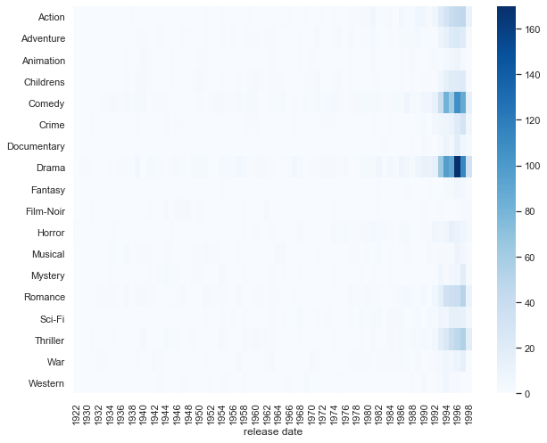

```python
# Visualise using a heatmap to show the whole dataset.
plt.figure(figsize=(10,8))
sns.heatmap(df_GenrePopularity.transpose(), cmap="Blues");
```

```python
# Observation:
# Perhaps unsurprisingly, given the observations of the Release Year distribution plot above,
# the fact that there is a concentration of release years after 1990 has the effect of
# hiding any trends from before 1990 that might otherwise be interesting to observe. One
# option to surface more of these trends is to instead present the heatmap based on the log10
# of the dataframe.
```

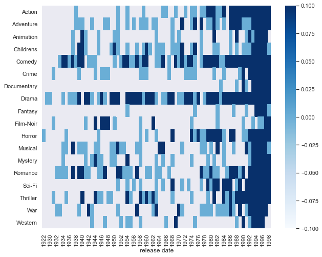

```python
# Use the apply function to produce a new dataframe which is the log of the dataframe visualised
# in the heatmap above
df_GenrePopularityLog = (df_GenrePopularity.apply(np.log10))

# Then produce the heatmap
plt.figure(figsize=(10,8))
sns.heatmap(df_GenrePopularityLog.transpose(), cmap="Blues");
```

```python
# Observations:
# Mapping the log of the dataframe still shows the concentration of releases after 1990, but
# now more of the trends for individual genres before 1990 are visible. Comedy and Drama
# stand out as having been more consistently popular compared to other genres, with the trends
# for genres like Action, Adventure, and Sci-Fi now visible from earlier.
```

### 9. Find the top 25 movies according to average ratings such that each movie has number of ratings more than 100 - 10 marks

Hint :

1. First find the movies that have more than 100 ratings(use merge, groupby and count). Extract the movie titles in a list.
2. Find the average rating of all the movies and sort them in the descending order. You will have to use the .merge() function to reach to a data set through which you can get the names and the average rating.
3. Use isin(list obtained from 1) to filter out the movies which have more than 100 ratings.

Note: This question will need you to research about groupby and apply your findings. You can find more on groupby on https://realpython.com/pandas-groupby/.

```python
# My approach is to use the Ratings data and first prepare a DataFrameGroupBy
# which is grouped by movie id, then create a DataFrame using the .count()
# and .mean() values, then drop rows with fewer than 100 ratings. This DataFrame
# is then inner merged with the Movies data - this does the filtering in one step

# Create a working copy of the Ratings DataFrame
df = df_Ratings.copy()

# Drop the superfluous columns
df.drop(labels=['user id','timestamp'], axis=1, inplace=True)

# Create a DataFrameGroupBy using groupby on 'movie id', and create a new DataFrame
# populated with the .count() value - gives the number of times the 'movie id' appears
# in the Ratings observations
df_TopRatings = pd.DataFrame(df.groupby('movie id').count())

# Now add the average rating to the new DataFrame, and tidy up the labels
df_TopRatings['average rating'] = df.groupby('movie id').mean()
df_TopRatings.rename(columns = {'rating':'number of ratings'}, inplace=True)

# Find the indexes for where there are fewer than 100 ratings and drop them
indexNames = df_TopRatings[df_TopRatings['number of ratings'] < 100].index
df_TopRatings.drop(indexNames, inplace=True)

# Create a new DataFrame with an inner merge of the original Movies data and the
# new DataFrame which now contains movie id, number of ratings, and average rating
# only for movies with more than 100 ratings. Inner merge on 'movie id' excludes all
# movies with fewer than 100 ratings.
df_TopMovies = pd.merge(df_Movies, df_TopRatings, how='inner', on='movie id')

# Sort the DataFrame by 'average rating', with ascending=False so the sorting is highest
# to lowest average rating
df_TopMovies.sort_values(by='average rating', ascending=False, inplace=True)

# Create the finished DataFrame by extracting the first 25 rows
df_Top25Movies = df_TopMovies.iloc[0:25]

# This now contains the top 25 movies by sorted by average rating, for only movies
# with more than 100 ratings
df_Top25Movies
```

|  | movie id | movie title | release date | unknown | Action | Adventure | Animation | Childrens | Comedy | Crime | ... | Horror | Musical | Mystery | Romance | Sci-Fi | Thriller | War | Western | number of ratings | average rating |
| --- | --- | --- | --- | --- | --- | --- | --- | --- | --- | --- | --- | --- | --- | --- | --- | --- | --- | --- | --- | --- | --- |
| 232 | 408 | Close Shave, A | 28-Apr-1996 | 0 | 0 | 0 | 1 | 0 | 1 | 0 | ... | 0 | 0 | 0 | 0 | 0 | 1 | 0 | 0 | 112 | 4.491071 |
| 202 | 318 | Schindler's List | 01-Jan-1993 | 0 | 0 | 0 | 0 | 0 | 0 | 0 | ... | 0 | 0 | 0 | 0 | 0 | 0 | 1 | 0 | 298 | 4.466443 |
| 91 | 169 | Wrong Trousers, The | 01-Jan-1993 | 0 | 0 | 0 | 1 | 0 | 1 | 0 | ... | 0 | 0 | 0 | 0 | 0 | 0 | 0 | 0 | 118 | 4.466102 |
| 262 | 483 | Casablanca | 01-Jan-1942 | 0 | 0 | 0 | 0 | 0 | 0 | 0 | ... | 0 | 0 | 0 | 1 | 0 | 0 | 1 | 0 | 243 | 4.456790 |
| 29 | 64 | Shawshank Redemption, The | 01-Jan-1994 | 0 | 0 | 0 | 0 | 0 | 0 | 0 | ... | 0 | 0 | 0 | 0 | 0 | 0 | 0 | 0 | 283 | 4.445230 |
| 293 | 603 | Rear Window | 01-Jan-1954 | 0 | 0 | 0 | 0 | 0 | 0 | 0 | ... | 0 | 0 | 1 | 0 | 0 | 1 | 0 | 0 | 209 | 4.387560 |
| 7 | 12 | Usual Suspects, The | 14-Aug-1995 | 0 | 0 | 0 | 0 | 0 | 0 | 1 | ... | 0 | 0 | 0 | 0 | 0 | 1 | 0 | 0 | 267 | 4.385768 |
| 22 | 50 | Star Wars | 01-Jan-1977 | 0 | 1 | 1 | 0 | 0 | 0 | 0 | ... | 0 | 0 | 0 | 1 | 1 | 0 | 1 | 0 | 583 | 4.358491 |
| 99 | 178 | 12 Angry Men | 01-Jan-1957 | 0 | 0 | 0 | 0 | 0 | 0 | 0 | ... | 0 | 0 | 0 | 0 | 0 | 0 | 0 | 0 | 125 | 4.344000 |
| 72 | 134 | Citizen Kane | 01-Jan-1941 | 0 | 0 | 0 | 0 | 0 | 0 | 0 | ... | 0 | 0 | 0 | 0 | 0 | 0 | 0 | 0 | 198 | 4.292929 |
| 239 | 427 | To Kill a Mockingbird | 01-Jan-1962 | 0 | 0 | 0 | 0 | 0 | 0 | 0 | ... | 0 | 0 | 0 | 0 | 0 | 0 | 0 | 0 | 219 | 4.292237 |
| 219 | 357 | One Flew Over the Cuckoo's Nest | 01-Jan-1975 | 0 | 0 | 0 | 0 | 0 | 0 | 0 | ... | 0 | 0 | 0 | 0 | 0 | 0 | 0 | 0 | 264 | 4.291667 |
| 55 | 98 | Silence of the Lambs, The | 01-Jan-1991 | 0 | 0 | 0 | 0 | 0 | 0 | 0 | ... | 0 | 0 | 0 | 0 | 0 | 1 | 0 | 0 | 390 | 4.289744 |
| 260 | 480 | North by Northwest | 01-Jan-1959 | 0 | 0 | 0 | 0 | 0 | 1 | 0 | ... | 0 | 0 | 0 | 0 | 0 | 1 | 0 | 0 | 179 | 4.284916 |
| 68 | 127 | Godfather, The | 01-Jan-1972 | 0 | 1 | 0 | 0 | 0 | 0 | 1 | ... | 0 | 0 | 0 | 0 | 0 | 0 | 0 | 0 | 413 | 4.283293 |
| 182 | 285 | Secrets & Lies | 04-Oct-1996 | 0 | 0 | 0 | 0 | 0 | 0 | 0 | ... | 0 | 0 | 0 | 0 | 0 | 0 | 0 | 0 | 162 | 4.265432 |
| 173 | 272 | Good Will Hunting | 01-Jan-1997 | 0 | 0 | 0 | 0 | 0 | 0 | 0 | ... | 0 | 0 | 0 | 0 | 0 | 0 | 0 | 0 | 198 | 4.262626 |
| 299 | 657 | Manchurian Candidate, The | 01-Jan-1962 | 0 | 0 | 0 | 0 | 0 | 0 | 0 | ... | 0 | 0 | 0 | 0 | 0 | 1 | 0 | 0 | 131 | 4.259542 |
| 255 | 474 | Dr. Strangelove or: How I Learned to Stop Worr... | 01-Jan-1963 | 0 | 0 | 0 | 0 | 0 | 0 | 0 | ... | 0 | 0 | 0 | 0 | 1 | 0 | 1 | 0 | 194 | 4.252577 |
| 95 | 174 | Raiders of the Lost Ark | 01-Jan-1981 | 0 | 1 | 1 | 0 | 0 | 0 | 0 | ... | 0 | 0 | 0 | 0 | 0 | 0 | 0 | 0 | 420 | 4.252381 |
| 259 | 479 | Vertigo | 01-Jan-1958 | 0 | 0 | 0 | 0 | 0 | 0 | 0 | ... | 0 | 0 | 1 | 0 | 0 | 1 | 0 | 0 | 179 | 4.251397 |
| 198 | 313 | Titanic | 01-Jan-1997 | 0 | 1 | 0 | 0 | 0 | 0 | 0 | ... | 0 | 0 | 0 | 1 | 0 | 0 | 0 | 0 | 350 | 4.245714 |
| 272 | 511 | Lawrence of Arabia | 01-Jan-1962 | 0 | 0 | 1 | 0 | 0 | 0 | 0 | ... | 0 | 0 | 0 | 0 | 0 | 0 | 1 | 0 | 173 | 4.231214 |
| 263 | 484 | Maltese Falcon, The | 01-Jan-1941 | 0 | 0 | 0 | 0 | 0 | 0 | 0 | ... | 0 | 0 | 1 | 0 | 0 | 0 | 0 | 0 | 138 | 4.210145 |
| 93 | 172 | Empire Strikes Back, The | 01-Jan-1980 | 0 | 1 | 1 | 0 | 0 | 0 | 0 | ... | 0 | 0 | 0 | 1 | 1 | 0 | 1 | 0 | 367 | 4.204360 |

25 rows × 24 columns